# MachineLearning Project

Lei Ying

March 5, 2016

# Summary

Using devices such as Jawbone Up, Nike FuelBand, and Fitbit it is now possible to collect a large amount of data about personal activity relatively inexpensively. These type of devices are part of the quantified self movement - a group of enthusiasts who take measurements about themselves regularly to improve their health, to find patterns in their behavior, or because they are tech geeks. One thing that people regularly do is quantify how much of a particular activity they do, but they rarely quantify how well they do it. In this project, your goal will be to use data from accelerometers on the belt, forearm, arm, and dumbell of 6 participants.

Data

The training data for this project are available here:

https://d396qusza40orc.cloudfront.net/predmachlearn/pml-training.csv

The test data are available here:

https://d396qusza40orc.cloudfront.net/predmachlearn/pml-testing.csv

The data for this project come from this source: http://groupware.les.inf.puc-rio.br/har.

# Get and Clean Data

## Download data

```r
library(caret)
library(dplyr)
```

```r
library(curl)

set.seed(3223)

download.file("https://d396qusza40orc.cloudfront.net/predmachlearn/pml-training.csv", destfile="pmlTraining.csv")
download.file("https://d396qusza40orc.cloudfront.net/predmachlearn/pml-testing.csv", destfile="pmlTesting.csv")

training <- read.csv("pmlTraining.csv", header=TRUE, na.strings=c("NA", " "))
dim(training)
```

```
## [1] 19622   160
```

```r
testing <- read.csv("pmlTesting.csv", header=TRUE, na.strings=c("NA", " "))
```

## Clean data

traning data set is 19622 X 160 data frame. Some columns contain many NA and missing value. These columns must be removed before modeling.

```r
# remove column 1 to 7
training <- subset(training, select=-c(1:7))
testing <- subset(testing, select=-c(1:7))

# Identify and select columns with no NA or missing value
training_fill <- training[, (colSums(is.na(training)) == 0)]
testing_fill <- testing[, (colSums(is.na(testing)) == 0)]
name_testing_fill <- colnames(testing_fill[, 1:52])

training_fill <- training[, c(name_testing_fill, "classe")]
```

## Split training data set into training data set (70%) to establish model and validation data set (30%) for cross validation.

```r
train <- createDataPartition(y=training_fill$classe, p=0.7, list=FALSE)
TrainSet <- training_fill[train,]
TestSet <- training_fill[-train,]
dim(TrainSet)
```

```
## [1] 13737    53
```

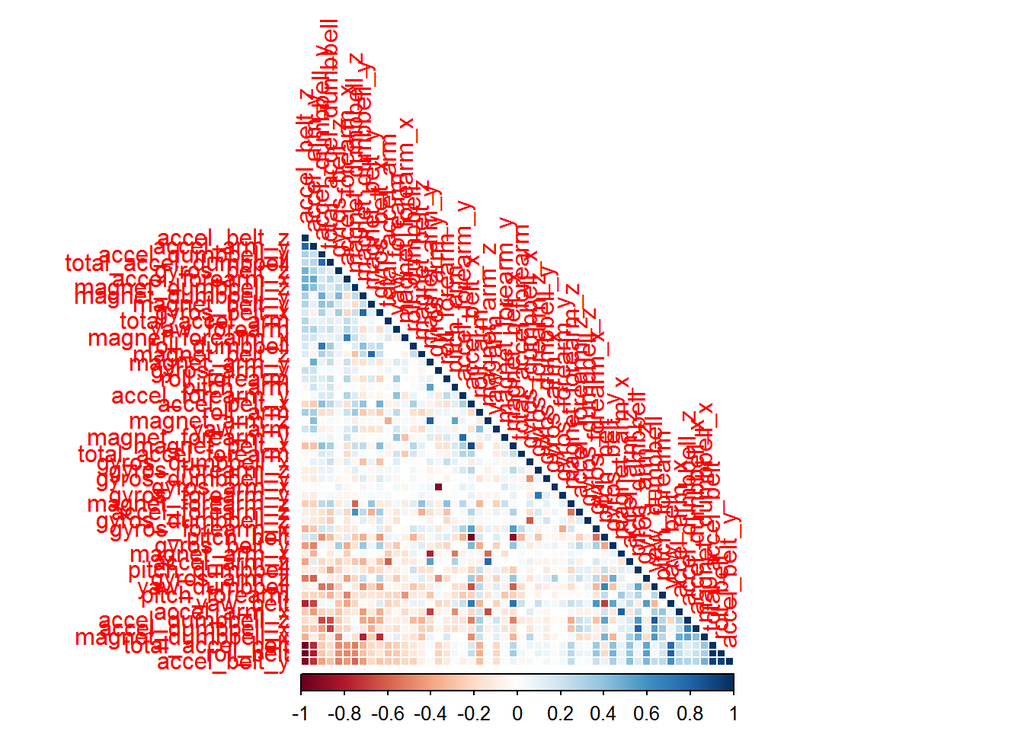

```r
library(corrplot)
corr <- cor(TrainSet[, 1:52])
corrplot(corr, order="FPC", method="color", type="lower")
```

From this plot, we can see there are several variables highly correlated. These variables should be removed before establish prediction model. This time we set up a cutoff of 0.95 of correlation.

```r
corr_value <- abs(cor(TrainSet[, -dim(TrainSet)[2]]))
diag(corr_value) <-0

correlated_var <- findCorrelation(corr_value, verbose=FALSE, cutoff=0.95)
TrainSet <- TrainSet[, -c(correlated_var)]
dim(TrainSet)
```

```
## [1] 13737    50
```

Now we have 49 variables for model prediction.

## Modeling training dataset

We use Random Forest algorithm to model TrainSet dataset

```r
library(randomForest)
fit_rf <- train(classe ~., data=TrainSet, method="rf", trControl = trainControl(method = "cv", number = 4), importance = TRUE)
fit_rf
```

```
## Random Forest
##
## 13737 samples
##    49 predictor
##     5 classes: 'A', 'B', 'C', 'D', 'E'
##
## No pre-processing
## Resampling: Cross-Validated (4 fold)
## Summary of sample sizes: 10303, 10301, 10303, 10304
## Resampling results across tuning parameters:
##
##   mtry  Accuracy   Kappa      Accuracy SD  Kappa SD
##    2    0.9884983  0.9854487  0.001021113  0.001292805
##   25    0.9909003  0.9884881  0.002488158  0.003147289
##   49    0.9826011  0.9779854  0.005978161  0.007565665
##
## Accuracy was used to select the optimal model using  the largest value.
## The final value used for the model was mtry = 25.
```

## Cross validation with TestSet dataset

```r
pre_rm <- predict(fit_rf, newdata=TestSet)
ConfMat <-confusionMatrix(pre_rm, TestSet$classe)
ConfMat
```

```
## Confusion Matrix and Statistics
##
##           Reference
## Prediction    A    B    C    D    E
##          A 1673   10    0    0    0
##          B    0 1123    6    0    0
##          C    0    5 1017    4    1
##          D    0    1    3  959    3
##          E    1    0    0    1 1078
##
## Overall Statistics
##
##                Accuracy : 0.9941
##                  95% CI : (0.9917, 0.9959)
##     No Information Rate : 0.2845
##     P-Value [Acc > NIR] : < 2.2e-16
##
##                   Kappa : 0.9925
##  Mcnemar's Test P-Value : NA
##
## Statistics by Class:
##
##                      Class: A Class: B Class: C Class: D Class: E
## Sensitivity            0.9994   0.9860   0.9912   0.9948   0.9963
## Specificity            0.9976   0.9987   0.9979   0.9986   0.9996
## Pos Pred Value         0.9941   0.9947   0.9903   0.9928   0.9981
## Neg Pred Value         0.9998   0.9966   0.9981   0.9990   0.9992
## Prevalence             0.2845   0.1935   0.1743   0.1638   0.1839
## Detection Rate         0.2843   0.1908   0.1728   0.1630   0.1832
## Detection Prevalence   0.2860   0.1918   0.1745   0.1641   0.1835
## Balanced Accuracy      0.9985   0.9923   0.9946   0.9967   0.9979
```

## Check Out-of-Sample Error

Here, we check out-of-sample error based on model accuracy.

```r
outErr <- 100-99.42
outErr
```

```
## [1] 0.58
```

## Evaluate Importance of Variables.

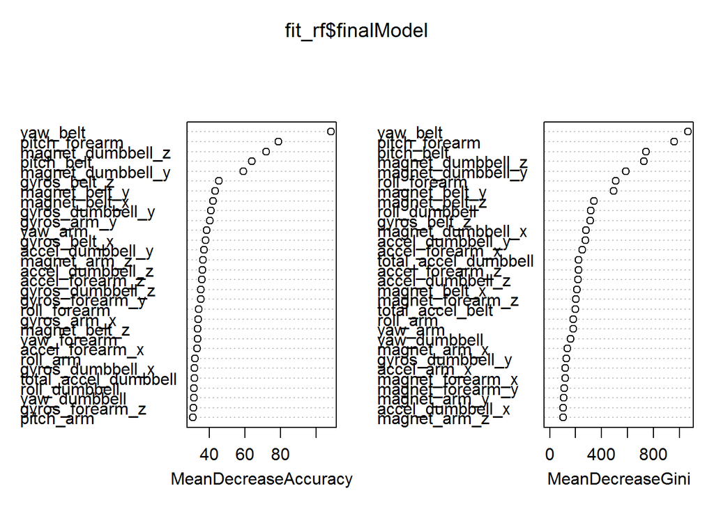

```r
Imp <- varImp(fit_rf, scale=FALSE)
varImpPlot(fit_rf$finalModel, sort=TRUE, scale=TRUE)
```

## Predict Results in Read Test Dataset

```r
final_test <- predict(fit_rf, testing_fill)
final_test
```

```
##  [1] B A B A A E D B A A B C B A E E A B B B
## Levels: A B C D E
```